# TileMap

# TileMap provides a grid to store data

The `TileMap` node draws textures on a grid, allowing you to paint repeating patterns and design levels efficiently. This approach to creating maps has been widely used in all sorts of 2D games for decades.

In Godot, you can use the `TileMap` node to draw side-scrolling, top-down, or isometric worlds using the built-in map editor.

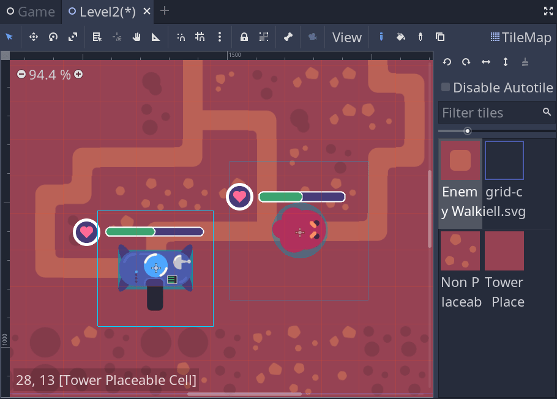

Note that the experience creating and using tilesets in Godot 3 can leave a bit to be desired. It’s perfectly usable even for larger games, but the interface can be a little tedious at times.

Fortunately, the Godot developers are working on it. They hired a developer specifically to redesign the system and interface from scratch.

You can get a glimpse of the redesign here: [Tiles editor progress report #3](https://godotengine.org/article/tiles-editor-progress-3)

[figure not shown]

In this guide, you will learn to:

- Use autotiles to create a platformer’s background.
- Use the `TileMap` node’s isometric mode.
- Make a character die when touching lava floor tiles.
- Place units on a grid.
- Occlude 2D lights with the floor.

Contents:

Contents:

- Setting up a TileMap
  - Creating a TileSet resource
  - Creating a single tile
- TileMap’s key features
  - Collide with 2D physics
  - Combine multiple tiles into one autotile
- How to use a TileMap in practice
  - Create stylized platformer levels with autotiles
  - Create an isometric dungeon
  - React to lava floor tiles
  - Place army units on the grid
  - Block light in 2D
- Your questions
  - How do I make my TileMap collide with the player?
  - What’s the difference between a single tile and an autotile?
  - How do I randomize the placement of tiles?
- Troubleshooting
  - When running the game, there are gaps between my tiles
  - The TileMap won’t collide with the player

## Setting up a TileMap

A `TileMap` works as a grid of cells, all of the same size. The first thing to do when creating one is to set the cells’ size.

You can do so using the *Cell -> Size* property.

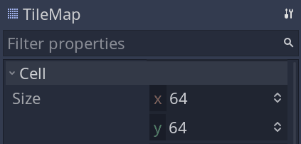

### Creating a TileSet resource

By default, all grid cells are empty. You need a `TileSet` resource to fill cells with tiles.

1. Click “[empty]” on the *Tile Set* property in the *Inspector* and create a *New TileSet*.
2. Click on the `TileSet` resource to open the `TileSet` editor in the bottom panel.
3. There, click the plus sign and select an image containing tiles.

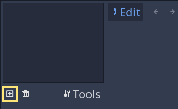

A tileset is a picture that typically contains many tiling textures, all of the same size.

Here’s an example from [Kenney’s assets](https://kenney.nl/).

[figure not shown]

### Creating a single tile

In Godot 3, you can create three kinds of tiles inside of a `TileSet` resource:

- A single tile.
- An autotile.
- An atlas tile.

The simplest of the three is a single tile. To create one:

1. Click *New Single Tile* in the top right of the `TileSet` editor.
2. Click and drag a region over corresponding to the tile in your source image.

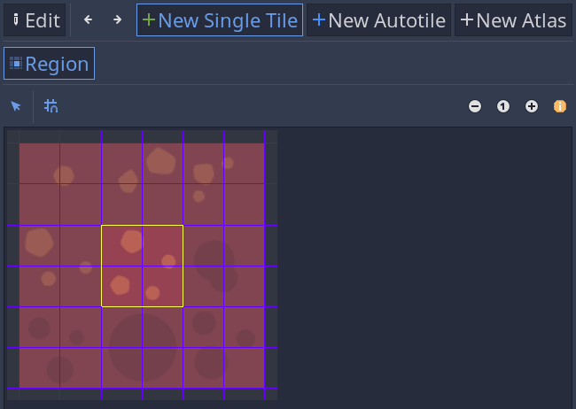

Once you created a tile, you can paint it on your `TileMap`.

To do so:

1. Select your `TileMap` node again.
2. In the vertical tilemap toolbar that appears next to the *Inspector*, click the tile you want to paint with.
3. In the toolbar, ensure the paint mode is active by clicking the pencil icon.
4. Click and drag in the viewport to draw copies of your tile.

That’s the absolute basics. To learn more, you can watch our video tutorial dedicated to creating tilesets in Godot: Using the Tileset Editor in Godot 3.1.

[figure not shown]

Most of it is still relevant as of Godot 3.4.

## TileMap’s key features

Here are some key features of the `TileMap` node.

### Collide with 2D physics

`TileMap` nodes can collide with 2D physics bodies to provide level geometry. They can also make Area2D nodes emit the `body_entered` signal.

When editing a `TileSet`, you can add collision shapes to individual tiles:

1. Click on the tile to edit.
2. Press `2` to enter collision mode.
3. Press `Shift`+`R` to add a rectangle.
4. Drag the mouse over the selected tile.

For more complicated tile shapes, you can create a new polygon with `Shift`+`P`. This gives you more control over the points of the collision shape.

Once you set the collision shapes, you can set the `TileMap`’s physics layer by adjusting the *Collision -> Layer* and *Collision -> Mask* properties.

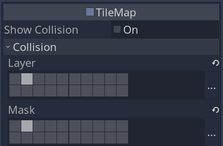

### Combine multiple tiles into one autotile

Autotiles can change the appearance of a tile based on its surrounding tiles. A common example of dynamically adjusting tiles is in games with road and path-building, like *SimCity* and *Rollercoaster Tycoon*:

[figure not shown]

*Game: RollerCoaster Tycoon (1999)*

Once set up, you can focus on creating the world’s geometry without having to rotate or flip any tiles. These next two sections cover how to create an image for *Autotiling* and set up an *Autotile* in the `TileSet` editor.

#### Creating an Autotile image

To create a tileset prepared for autotiling, you should use a template to make sure your art matches the autotile system.

2x2 template:

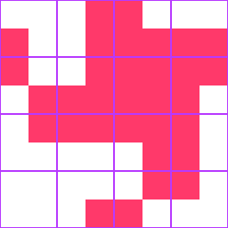

3x3 template:

[figure not shown]

*Images licensed under Creative Commons Attribution 3.0, attributed to Juan Linietsky, Ariel Manzur, and the Godot community.*

You can find more bitmask templates and general tile templates for different top-down perspectives in the [Godot Docs Tutorial on Using TileMaps](https://docs.godotengine.org/en/stable/tutorials/2d/using_tilemaps.html#autotiles).

#### Setting up an Autotile

Once you created your autotile’s image texture, you can set it up in the `TileSet` editor.

1. Click *New Autotile*, enable snapping, and click anywhere on the image.
2. In the *Inspector*, set *Snap Options -> Step* to match your tiles’ size.
3. Click and drag on the image again to make the region match the autotile precisely.
4. In the *Inspector*, set *Selected Tile -> Subtile Size* to match the division of tiles on the image.
5. Set *Selected Tile -> Autotile Bitmask Mode* to 2x2, 3x3, or 3x3 (minimal) to match the template you used.
6. Press `5` to enable *Bitmask* mode.
7. Click the portions of the subtile to match the red squares that were on the template.

When you’re done setting up the *Autotile* to match the template, you should have a single *Autotile* with a bitmask that matches your tileset. The tileset we used for many of our demos uses a 3x3 (minimal) autotile bitmask mode.

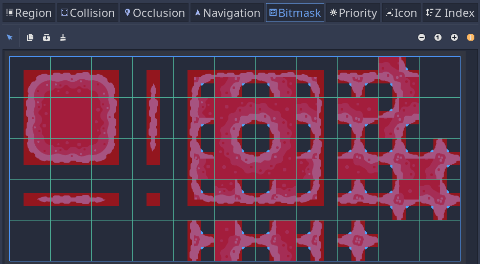

If you go back to select your `TileMap`, you should be able to place one tile and have multiple subtiles of the `TileSet` appear based on context.

## How to use a TileMap in practice

Now we’ll look at some concrete use cases for the `TileMap` node.

### Create stylized platformer levels with autotiles

The autotile system can look at the geometry of your tiles to stylize the corners and edges automatically.

Autotiles save you from creating and placing individual tiles for each corner or edge in a tileset image.

[figure not shown]

Following the Combine several images into one tile with Autotile section, you can set up autotiles to quickly create and edit platforms that look more authentic to the game world.

### Create an isometric dungeon

One of the alternate modes for a `TileMap` grid is *Isometric*. This lets you place images with an isometric perspective onto an isometric grid.

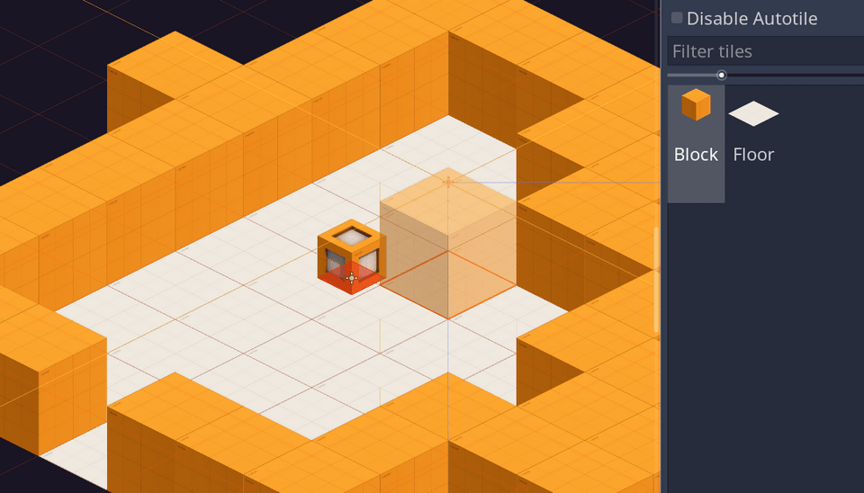

Creating an isometric `TileMap` for flat terrain (where no object can be behind a tile) is similar to creating a regular tileset.

However, introducing collidable walls and props presents some new challenges when creating a tileset:

- Colliding with isometric walls.
- Sorting objects in front and behind isometric walls on the tilemap.

When building collision shapes for the wall, we don’t always want to cover the entire wall with collision.

We only care about where the bottom of the wall would touch the ground, using our isometric perspective.

When it comes to sorting objects, the `YSort` node is a tool of choice.

A `YSort` node sets the z-index of its children automatically based on their y position. `YSort` children that are lower on the screen (with a larger y position) will appear in front of their siblings.

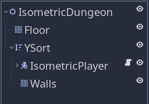

In the above example, we never want anything to appear behind the floor, so we leave them in a separate `TileMap` node.

Only the wall cells and the player need sorting.

To have the `TileMap` respond to the `YSort`, enable *Cell* -> *Y Sort*. This makes each cell a part of the `YSort` calculations.

This won’t always produce successful results for a few reasons:

- The wall tile: the center of its footprint (where it makes contact with the ground) should match the center of its cell.
- The player sprite: the center of the player’s feet should be the origin of the player’s scene.

For the wall, we fix this by changing the height of the tile using *Selected Tile -> Tex Offset* in the `TileSet` editor.

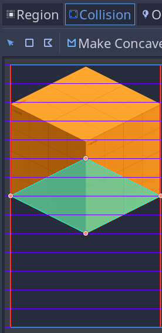

For the player sprite, we align the base of the image with the parent `KinematicBody2D` controlling its position.

[figure not shown]

The immediate child of the `YSort` determines its drawing order.

In the example below, the player’s child sprite will use the parent *IsometricPlayer* node, a `KinematicBody2D`, to determine its drawing order.

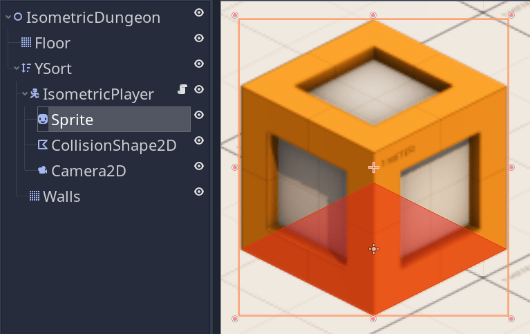

### React to lava floor tiles

If you want to add hazards to a level using `TileMap`, you’ll have to determine which tile you hit and how the player should react to different tiles.

The fast way to react to specific tiles is to put all tiles of a certain type (lava, spikes, etc.) on their own `TileMap` node and place them on a separate physics layer for hazards.

The player can use an `Area2D` node to detect bodies on that physics layer.

In the example below, we have an `Area2D` node named *HurtBox* with its collision mask set to the *Lava* `TileMap`’s physics layer.

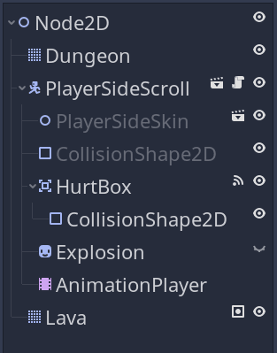

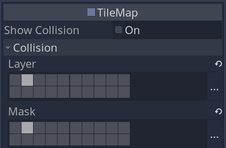

Note: you can learn more about hit and hurt boxes in the Area2D guide.

First, we connect an `Area2D` child to our script with a callback function:

```
onready var _hurt_box: Area2D = $HurtBox
onready var _anim_player_explosion: AnimationPlayer = $AnimationPlayer


func _ready() -> void:
    _hurt_box.connect("body_entered", self, "_on_Area2D_body_entered")
```

Optionally, if we want to restrict our `Area2D` to only react to `TileMap` nodes, we can `return` from the callback early if the body’s class isn’t a `TileMap`.

We can check the group of the node we hit in code:

```
func _on_Area2D_body_entered(body: Node) -> void:
    if not body.is_class("TileMap"):
        return

    if body.is_in_group("Hazard"):
        _anim_player_explosion.queue("explode")
```

Another benefit to using a `TileMap` dedicated to hazards is adding shaders to adjust the look of the tiles on the `TileMap`.

Here we’ve added a scrolling shader to the *Lava* `TileMap`, so it appears more like a liquid:

```
shader_type canvas_item;

const float SPEED = 0.1;

void fragment(){
    vec2 uv = UV;
    uv.x = 0.501 + mod(uv.x - TIME * SPEED, 0.5);
    COLOR = texture(TEXTURE, uv);
}
```

Although we used a second `TileMap` for hazards, you could also use an `Area2D` instead of a `TileMap` and use the `area_entered` signal instead on the player’s `Area2D` to detect danger.

You can also use `PhysicsServer`, `Physics2DDirectSpaceState`, and `Physics2DDirectBodyState` to find the tile that the player hit, which would allow reacting to hazards on a single `TileMap`.

We chose the second `TileMap` method because it gave us quick access to adjust the materials of one tile, and it’s easier to understand and implement at a glance for other projects.

### Place army units on the grid

In strategy games like *StarCraft II*, you’re able to place units and build structures on a grid.

Placing a building is not only visual; it also adds a new game object that can move and interact with other objects in the world.

[figure not shown]

*Game: StarCraft II (2010)*

You can recreate this in 2D using a `TileMap`, and prevent players from placing units on invalid locations like lakes.

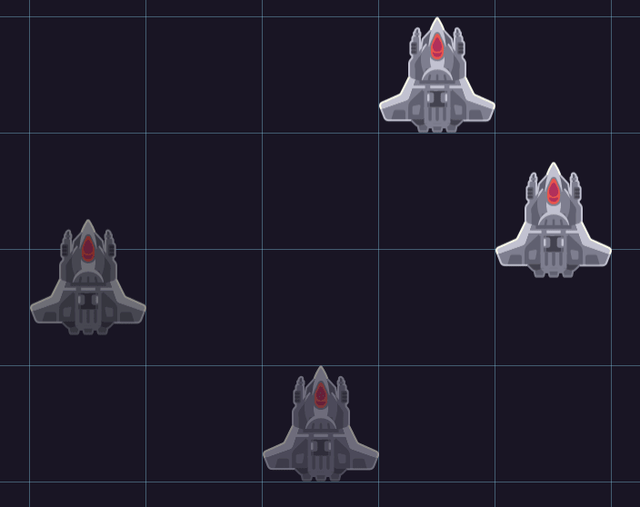

In this example, our `TileMap` has three potential states per tile:

- Empty slot.
- A preview tile showing the unit we’re about to place.
- An occupied tile that we cannot remove.

We use enumerations to distinguish each tile index that the `TileMap` is using for these cell states.

These tile indexes are in the `TileSet` resource. `-1` is always an empty cell.

```
extends Node2D

export var unit_to_instance: PackedScene

enum {
    UNIT_PREVIEW_TILE = 0,
    EMPTY_TILE = -1,
}

# The TileMap is used to show a preview cursor. Used in update_tilemap_preview().
var preview_cursor_position := Vector2.ZERO

# Holds our cursor, as well as other building tiles that already occupy the grid.
onready var tilemap: TileMap = $TileMap
```

Using `_unhandled_input()`, you can get the position of the mouse cursor and send it to a function that will pass it to the `TileMap`:

```
func _unhandled_input(event: InputEvent) -> void:
    if event is InputEventMouseMotion:
        update_tilemap_preview(event.position)

    if event is InputEventMouseButton or event is InputEventScreenTouch:
        if event.pressed:
            create_unit_at(event.position)
```

We can input a 2D position, send it to the `TileMap` using `world_to_map()`, and get a grid-oriented position out using `map_to_world()`.

This gives us a position to place a new ship on the grid.

```
## Places a PackedScene, with its position snapped to the TileMap.
func create_unit_at(coordinates: Vector2) -> void:
    # Snap input coordinates to the TileMap.
    var map_position := tilemap.world_to_map(coordinates)
    var selected_tile := tilemap.get_cellv(map_position)
    # If update_tilemap_preview() didn't put the cursor here, don't put a unit here either.
    if selected_tile != UNIT_PREVIEW_TILE:
        return
    var new_unit := unit_to_instance.instance()
    # Get a world position out of the map so our unit placement matches the grid.
    new_unit.position = tilemap.map_to_world(map_position)
    add_child(new_unit)
```

We can also fill the `TileMap` with a preview tile to show where we will place a unit.

We can take coordinates passed from `_unhandled_input()` and call `get_cellv()` on the `TileMap` to determine if the cell is empty or not.

```
## Updates the preview cursor, checks if it would overlap an already-occupied tile.
func update_tilemap_preview(coordinates: Vector2) -> void:
    # Don't show the preview over an existing tile.
    if tilemap.get_cellv(tilemap.world_to_map(coordinates)) != EMPTY_TILE:
        return
    # Empty the previous cursor position.
    tilemap.set_cellv(preview_cursor_position, EMPTY_TILE)
    # Update the cursor position.
    preview_cursor_position = tilemap.world_to_map(coordinates)
    # Use the cursor position to place the unit preview tile.
    tilemap.set_cellv(preview_cursor_position, UNIT_PREVIEW_TILE)
```

With the unit creation script done, now it’s up to us to determine what to put in it.

We went for a ship that slowly moves and disappears after enough time has passed, but instancing any other scene would work just as well:

```
func _ready() -> void:
    # The "Die" animation calls queue_free() on this node.
    _timer.connect("timeout", _anim_player, "play", ["Die"])


func _physics_process(_delta: float) -> void:
    var velocity = _direction * SPEED
    move_and_slide(velocity)
```

### Block light in 2D

In Godot, tiles can occlude light and cast shadows when combined with a `Light2D` node.

[figure not shown]

You can add a `Light2D` to cast light from your player:

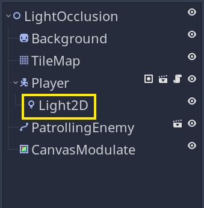

Then, you can add occluder shapes to an autotile to block light.

You can use the tileset editor to adjust the shape of the occluders for each subtile:

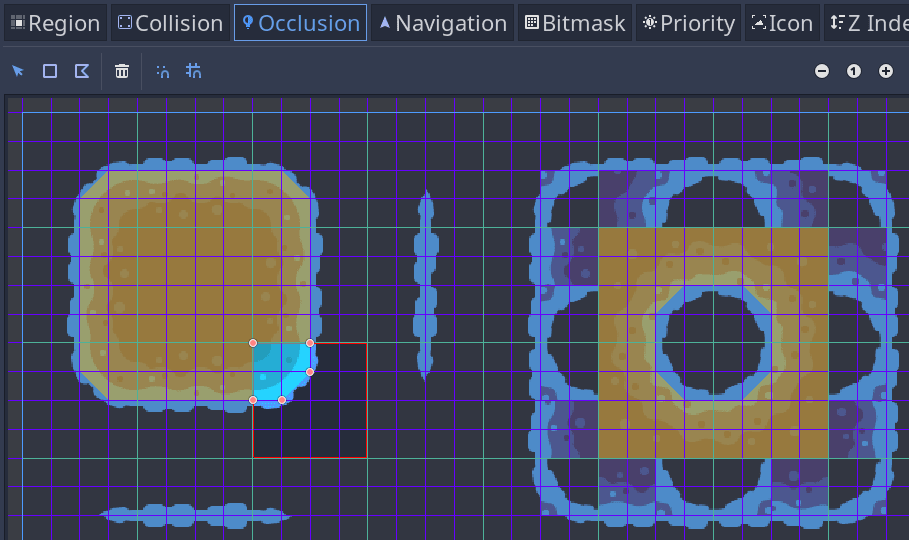

If you want to check the line of sight between the player and the enemy, you can read the RayCast2D guide.

We chose to use a semi-transparent `CanvasModulate` to obscure objects in the shadows without making them impossible to see.

You can configure your light and shadows to achieve a lot of different effects.

Read the [official Godot tutorial on light and shadows](https://docs.godotengine.org/en/stable/tutorials/2d/2d_lights_and_shadows.html) to learn more.

## Your questions

### How do I make my TileMap collide with the player?

Add a collision shape to each tile you’re using.

If you’re using autotiles, you can assign collision shapes to each subtile.

Make sure that the collision shape is convex. If it becomes concave, press the *Make Concave* button in the tileset editor.

### What’s the difference between a single tile and an autotile?

A single tile interprets the exact region set in the `TileSet` editor as the entire tile.

Meanwhile, the region of an *Autotile* can be an image with multiple tiles.

The appearance of each cell using the autotile changes depending on its surrounding cells. Two things determine the appearance of an autotile:

- Bitmask - refer to Setting up an Autotile.
- Icon - how the tile appears in the palette, or when there’s no correct bitmask setting for the current state of surrounding tiles.

### How do I randomize the placement of tiles?

Use an autotile and make the tiles you want to appear randomly have matching bitmasks.

When multiple subtiles use the same bitmask, the node will randomly choose between those subtiles when the corresponding tile geometry appears in the `TileMap`.

You can make tiles appear more often than others by pressing `6` to edit the subtile’s *Priority*.

If you want to randomize the placement of single tiles, you can also write a script that randomly picks from the available set of tiles:

```
_tilemap.set_cell(0, 0, randi() % NUMBER_OF_TILES)
```

You can watch our free tutorial covering the topic of procedural map generation - [Intro to GDScript 2: Procedural Map Generation Tutorial on YouTube](https://youtu.be/1JcrXlD-iCU).

## Troubleshooting

### When running the game, there are gaps between my tiles

Game engines draw tiles in such a way visual artifacts can appear.

This happens pretty much regardless of the engine:

- When smoothly panning the view.
- When zooming the view in and out.

The reason it happens is the graphics cards using different strategies to sample pixels of your source texture and map it to the screen, which can cause it to sample a pixel from a neighboring tile. We call this bleeding and it also happens with 3D objects.

The definitive fix to this requires to design tile set images with a few pixels between each tile texture.

Ideally, you want each tile to have a border around it that replicates the tile’s pixels. This gets rid of all artifacts.

Godot’s `TileSet` editor offers snapping options to take that into account when drawing regions around tiles.

Lastly, for a quick but incomplete fix, you can try the following project settings:

- *Rendering -> 2d -> Snapping -> Use Gpu Pixel Snap*. This works well for pixel art games but makes you lose smoothness when panning the game view.
- *Rendering -> Batching -> Precision -> Uv Contract*. This can prevent visual gaps but also slightly squash the border of your textures.

You can use both settings together. They come in handy for game jams, prototypes, demos, and may also do the job for games with flat art styles, like our tower defense demo.

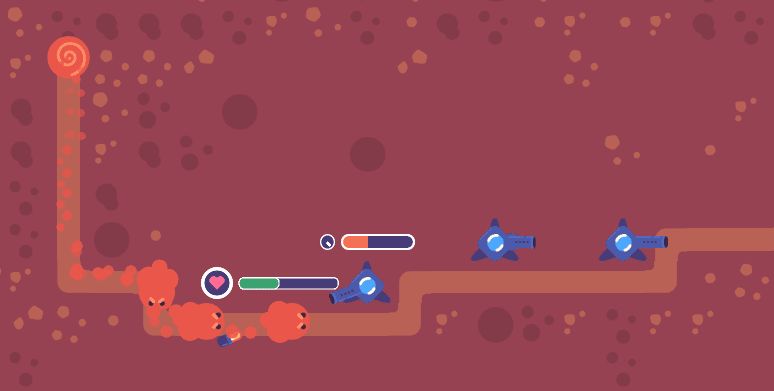

### The TileMap won’t collide with the player

Check the physics layers of your `TileMap` and your player.

Check that collision shapes are set on the tiles you’re using.

If some collision shapes work, but others don’t, make sure any concave shapes have *Make Concave* set and appear purple in the tileset editor.